# Virginia Code Walkthrough

Author

Joshua K. De La Torre

Introduction: This Code Walkthrough will use the joined_vacomparison dataset to analyze the electoral performance of presidential and gubernatorial candidates during the national elections. This walkthrough will be a step by step guide into the process of using datasets as potential sources for stories. This includes a comparison of total votes between candidates, % difference of votes, as well as steps to visualize them into tables and charts.

# Comparing Virginia Gov vs. Prez

```r
#used head to display top results inside the data set for inspection
head(joined_vacomparison)
```

```
# A tibble: 6 x 9
  locality       biden trump biden_pct trump_pct youngkin mcauliffe pct_youngkin
  <chr>          <dbl> <dbl>     <dbl>     <dbl>    <int>     <int>        <dbl>
1 ACCOMACK COUN~  7578  9172      44.7      54.1     7878      4948         61.1
2 ALBEMARLE COU~ 42466 20804      65.7      32.2    19141     31919         37.2
3 ALEXANDRIA CI~ 66240 14544      80.3      17.6    14013     43866         24.0
4 ALLEGHANY COU~  2243  5859      27.3      71.4     4530      1518         74.5
5 AMELIA COUNTY   2411  5390      30.6      68.3     4720      1617         74.2
6 AMHERST COUNTY  5672 11041      33.4      64.9     9731      3897         71
# ... with 1 more variable: pct_mcauliffe <dbl>
```

```r
#Next lines of code create an interactive version of the joined_vacomparison data table using the DT package.
#The code below adds the buttons and other interactive elements as well as telling the system which column to highlight.
#Adding in the filter also lets the system know that you want to be able to sort the table.

DT::datatable(joined_vacomparison,
              rownames = FALSE,
              filter = "top"# <--- NEW STUFF HERE
              )
```

| locality | biden | trump | biden_pct | trump_pct | youngkin | mcauliffe | pct_youngkin | pct_mcauliffe |
| --- | --- | --- | --- | --- | --- | --- | --- | --- |
| ACCOMACK COUNTY | 7578 | 9172 | 44.68 | 54.07 | 7878 | 4948 | 61.08 | 38.37 |
| ALBEMARLE COUNTY | 42466 | 20804 | 65.68 | 32.18 | 19141 | 31919 | 37.21 | 62.05 |
| ALEXANDRIA CITY | 66240 | 14544 | 80.28 | 17.63 | 14013 | 43866 | 24.02 | 75.2 |
| ALLEGHANY COUNTY | 2243 | 5859 | 27.34 | 71.43 | 4530 | 1518 | 74.52 | 24.97 |
| AMELIA COUNTY | 2411 | 5390 | 30.55 | 68.29 | 4720 | 1617 | 74.19 | 25.42 |
| AMHERST COUNTY | 5672 | 11041 | 33.35 | 64.93 | 9731 | 3897 | 71 | 28.43 |
| APPOMATTOX COUNTY | 2418 | 6702 | 26.09 | 72.31 | 5971 | 1438 | 80.26 | 19.33 |
| ARLINGTON COUNTY | 105344 | 22318 | 80.6 | 17.08 | 21548 | 73013 | 22.63 | 76.67 |
| AUGUSTA COUNTY | 10840 | 30714 | 25.64 | 72.65 | 26196 | 7231 | 77.93 | 21.51 |
| BATH COUNTY | 646 | 1834 | 25.83 | 73.33 | 1539 | 396 | 79.04 | 20.34 |

[output cut: 123 more lines]

```r
joined_vacomparison <- joined_vacomparison %>%
  mutate(
    locality = as_factor(locality),
    trump = as.factor(trump)
  )
```

```r
#continues process described in previous chunk. split for better comprehension
#creating the TestAnalysisTable allows us to export the a web page version of the table
VirginiaAnalysisTable <- DT::datatable(joined_vacomparison,
              rownames = FALSE,
              filter = "top",
              extensions = 'Buttons',
              options = list(   # <--- NEW STUFF STARTS HERE
                dom = 'Bfrtip',
                buttons = c('copy', 'csv', "excel")
              )) %>%
  DT::formatStyle('locality',  color = 'blue', fontWeight = 'bold')

# ... then just run this simple bit of code to export to html
DT::saveWidget(VirginiaAnalysisTable, "VirginiaAnalysisTable")
```

Include code to a new column to the dataset calculating the difference between the percentage of the vote Youngkin received and what Trump received.

```r
#created youngkinvstrump from joined_vacomparison. used group_by to put trump_pct and pct_youngkin into separate buckets by which all other data is grouped into
#used head() to inspect results
#created new data table from youngkinvstrump that adds a filter that subtracts the % votes trump received from youngkin's votes to compare the gap in votes and see who performed better in the election. this is under the new votemargin that is summarised to show only the three relevant columns
#used cbind to copy the votemargin column from pct_diff_YT into the original data set


youngkinvstrump <- (joined_vacomparison) %>%
  group_by(trump_pct, pct_youngkin)

head(youngkinvstrump)
```

```
# A tibble: 6 x 9
# Groups:   trump_pct, pct_youngkin [6]
  locality       biden trump biden_pct trump_pct youngkin mcauliffe pct_youngkin
  <fct>          <dbl> <fct>     <dbl>     <dbl>    <int>     <int>        <dbl>
1 ACCOMACK COUN~  7578 9172       44.7      54.1     7878      4948         61.1
2 ALBEMARLE COU~ 42466 20804      65.7      32.2    19141     31919         37.2
3 ALEXANDRIA CI~ 66240 14544      80.3      17.6    14013     43866         24.0
4 ALLEGHANY COU~  2243 5859       27.3      71.4     4530      1518         74.5
5 AMELIA COUNTY   2411 5390       30.6      68.3     4720      1617         74.2
6 AMHERST COUNTY  5672 11041      33.4      64.9     9731      3897         71
# ... with 1 more variable: pct_mcauliffe <dbl>
```

```r
pct_diff_YT <- youngkinvstrump %>%
  group_by(trump_pct, pct_youngkin) %>%
  summarise(votemargin=pct_youngkin-trump_pct)
joined_vacomparison<- cbind(joined_vacomparison, pct_diff_YT$votemargin)
```

Use this new column to find the Top 5 counties with the highest differences between Younkin/Trump percent, and then create a well-labeled chart to visualize them.

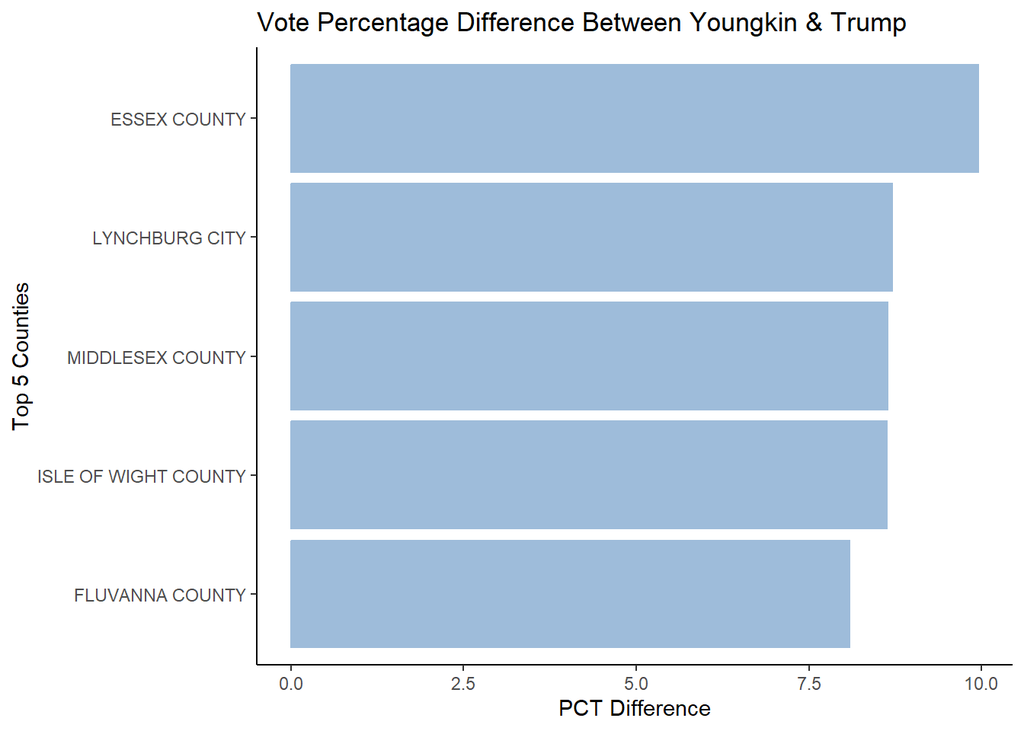

```r
#created new data set from joined_vacomparison that groups the data by locality but arranges them in order to show the 5 counties with biggest % difference in votes between Trump and Youngkin
#added - inside arrange() function to order votemargin with the highest values on top
#summarised votemargin into column called pctdifference for y value
#next set of code creates a chart from the youngkincounties data set created above with locality as x and pctdifference as y. Locality is x value because it is the column by which the performance of the candidates are being assessed
#x is reordered to order the idsplayed bars in the plot to go from the highest vote margin first and then descending order for a better visual analysis.
#coordflip changes the orientation of the chart, with no effects on the actual data displayed.
#next lines of code add x and y labels and a title for the chart, as well as theme_classic to add other simple visual touches to it

youngkincounties <- joined_vacomparison %>%
  group_by(locality)%>%
  arrange(-`pct_diff_YT$votemargin`)%>%
  head(5)%>%
  summarise(pctdifference=`pct_diff_YT$votemargin`)

youngkincounties %>%
  ggplot(aes(x = reorder(locality, pctdifference), y = pctdifference)) +
  geom_col(color = "#9ebcda", fill = "#9ebcda") +
  coord_flip() +
  scale_y_continuous(name = "PCT Difference", labels = scales::comma) +
  scale_x_discrete(name = "Top 5 Counties") +
  labs(title = "Vote Percentage Difference Between Youngkin & Trump") +
  theme_classic()
```

[figure not shown]

```r
#reloaded joined_vacomparison for a clear version of the file
#created new data set called youngkinwins that groups the other columns by the youngkin and trump columns and the localities using the group_by function. the data set arranged the youngkin and trump columns by the highest numeric value by adding a subtraction sign in from to order column from hieghest to lowest
#used summarise to create new column that adds combines the two grouped columns
#used head() to display only the top 5 results
#created new data set that uses mutate and janitor to calculate percentage of votes youngkin recieved comapred to trump
#created a chart to visualize results using the same process from the previous chart

joined_vacomparison <- readRDS(here("processed_data", "joined_vacomparison.rds"))

youngkinwins <- joined_vacomparison %>%
  group_by(locality, youngkin, trump) %>%
  arrange(-youngkin+trump)%>%
  summarise(pcthigh=youngkin+trump) %>%
  head(5)
youngkinhigh <- youngkinwins %>%
  mutate(
    pct_youngkin = janitor::round_half_up(youngkin / pcthigh * 100, 2), trump_pct = janitor::round_half_up(trump/ pcthigh *100, 2)
  ) %>%
  head(5)

youngkinhigh %>%
  ggplot(aes(x = reorder(locality, pcthigh), y = pcthigh)) +
  geom_col(color = "#9ebcda", fill = "#9ebcda") +
  coord_flip() +
  scale_y_continuous(name = "Vote %", labels = scales::comma) +
  scale_x_discrete(name = "Counties") +
  labs(title = "Top 5 Counties for Youngkin vs Trump") +
  theme_classic()
```

```r
#loaded fresh version of original dataset
#created new dataset grouped around the columns for % of votes mcauliffe and trump got
#from this I created another dataset summarises the two columns into a new column called votemargin
#I then used cbind to merge the votemargin column from this data set and put it into the old dataset

joined_vacomparison <- readRDS(here("processed_data", "joined_vacomparison.rds"))

McCauliffvstrump <- (joined_vacomparison) %>%
  group_by(pct_mcauliffe, trump_pct)

head(McCauliffvstrump)
```

```
# A tibble: 6 x 9
# Groups:   pct_mcauliffe, trump_pct [6]
  locality       biden trump biden_pct trump_pct youngkin mcauliffe pct_youngkin
  <chr>          <dbl> <dbl>     <dbl>     <dbl>    <int>     <int>        <dbl>
1 ACCOMACK COUN~  7578  9172      44.7      54.1     7878      4948         61.1
2 ALBEMARLE COU~ 42466 20804      65.7      32.2    19141     31919         37.2
3 ALEXANDRIA CI~ 66240 14544      80.3      17.6    14013     43866         24.0
4 ALLEGHANY COU~  2243  5859      27.3      71.4     4530      1518         74.5
5 AMELIA COUNTY   2411  5390      30.6      68.3     4720      1617         74.2
6 AMHERST COUNTY  5672 11041      33.4      64.9     9731      3897         71
# ... with 1 more variable: pct_mcauliffe <dbl>
```

[figure not shown]

```r
pct_diff_MCT <- McCauliffvstrump %>%
  group_by(trump_pct, pct_mcauliffe) %>%
  summarise(votemargin=pct_mcauliffe-trump_pct)
joined_vacomparison<- cbind(joined_vacomparison, pct_diff_MCT$votemargin)

#I then used this version of the data set to create yet another dataset, this time grouping #the entries around the locality column and arranging the votemargin column in order of #highest to lowest (by adding a minus sign to reverse the order the values are displayed) then used head() to cut off the output to only show the top 5
#I used summarise to create a new column using the above output which I then used to mutate a new data set that divides the % of votes columns for both mcauliffe and trump by the % difference multiplied by 100. I then used head to only show the top 5 results
#created a graph using the process I previously outlined

McCauliffecounties <- joined_vacomparison %>%
  group_by(pct_mcauliffe, trump_pct)%>%
  arrange(-pct_diff_MCT$votemargin)%>%
  summarise(pctdifference=pct_diff_MCT$votemargin) %>%
  head(5)
McCauliffecounties2 <- McCauliffecounties %>%
  mutate(pct_mcauliffe = janitor::round_half_up(pct_mcauliffe / pctdifference * 100, 2), trump_pct = janitor::round_half_up(trump_pct/ pctdifference *100, 2)
  ) %>%
  head(5)

McCauliffecounties2 %>%
  ggplot(aes(x = reorder(pct_mcauliffe, pctdifference), y = pctdifference)) +
  geom_col(color = "#9ebcda", fill = "#9ebcda") +
  coord_flip() +
  scale_y_continuous(name = "PCT Difference", labels = scales::comma) +
  scale_x_discrete(name = "Top 5 Counties") +
  labs(title = "Vote Percentage Difference Between McCauliffe & Trump") +
  theme_classic()
```

Based on your own analysis, explain a finding of your choosing, include a narrative explaining it to the audience and then create either a chart or table displaying it.

```r
#loaded fresh data set to create new data set grouped around the percentage of votes mcauliffe and youngkin recieved as well as the localities column to show where the votes came from
#used head to display only 5 results
#used summarise to create new column subtracting percentage of votes mcauliffe recieved with youngkin to create a breakdown of how much of the votes each candidate recieved in the tope 5 counties compared to each other
#used head() to inspect new dataset
#created another dataset that groups by percentage of votes for mcauliffe and youngkin and locality together

joined_vacomparison <- readRDS(here("processed_data", "joined_vacomparison.rds"))

governorrace <- (joined_vacomparison) %>%
  group_by(locality, pct_mcauliffe, pct_youngkin) %>%
  head(5) %>%
  summarise(votemargin = pct_youngkin-pct_mcauliffe)
head(governorrace)
```

```
# A tibble: 5 x 4
# Groups:   locality, pct_mcauliffe [5]
  locality         pct_mcauliffe pct_youngkin votemargin
  <chr>                    <dbl>        <dbl>      <dbl>
1 ACCOMACK COUNTY           38.4         61.1       22.7
2 ALBEMARLE COUNTY          62.0         37.2      -24.8
3 ALEXANDRIA CITY           75.2         24.0      -51.2
4 ALLEGHANY COUNTY          25.0         74.5       49.6
5 AMELIA COUNTY             25.4         74.2       48.8
```

```r
pct_diff_MY <- governorrace %>%
  group_by(locality, pct_mcauliffe, pct_youngkin) %>%
  summarise(votemargin=pct_youngkin-pct_mcauliffe)
```

Based on your own analysis, explain a second finding of your choosing, include a narrative explaining it to the audience and then create either a chart or table displaying it.

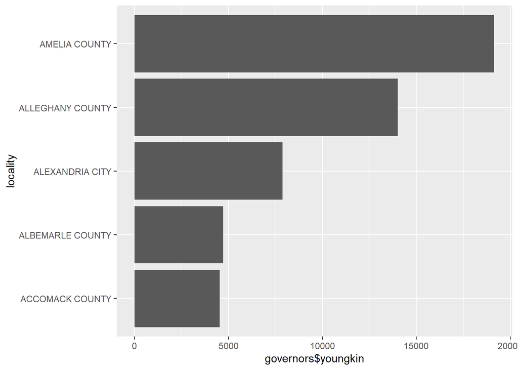

```r
#loaded fresh dataset
#used fresh data set to create data set grouped by the votes for youngkin and used head() to only display top 5 results
#created new data set grouped by the votes for youngkin and mcauliffe and locality to trace where the votes came from
#and used head() to only display top 5 results
#to graph the results I used ggplot to graph the governors data set using youngkin's votes as the x and locality as the y

joined_vacomparison <- readRDS(here("processed_data", "joined_vacomparison.rds"))

governorvotes <- (joined_vacomparison) %>%
  group_by(youngkin, mcauliffe) %>%
  head(5)

governors<- governorvotes %>%
  group_by(youngkin, mcauliffe)%>%
  head(5)%>%
  summarise(electionperformance = n())
ggplot(governorvotes, aes(x = governors$youngkin, y = locality)) +
  geom_col()+
  scale_fill_manual(values = c("#468189", "#9DBEBB"))
```

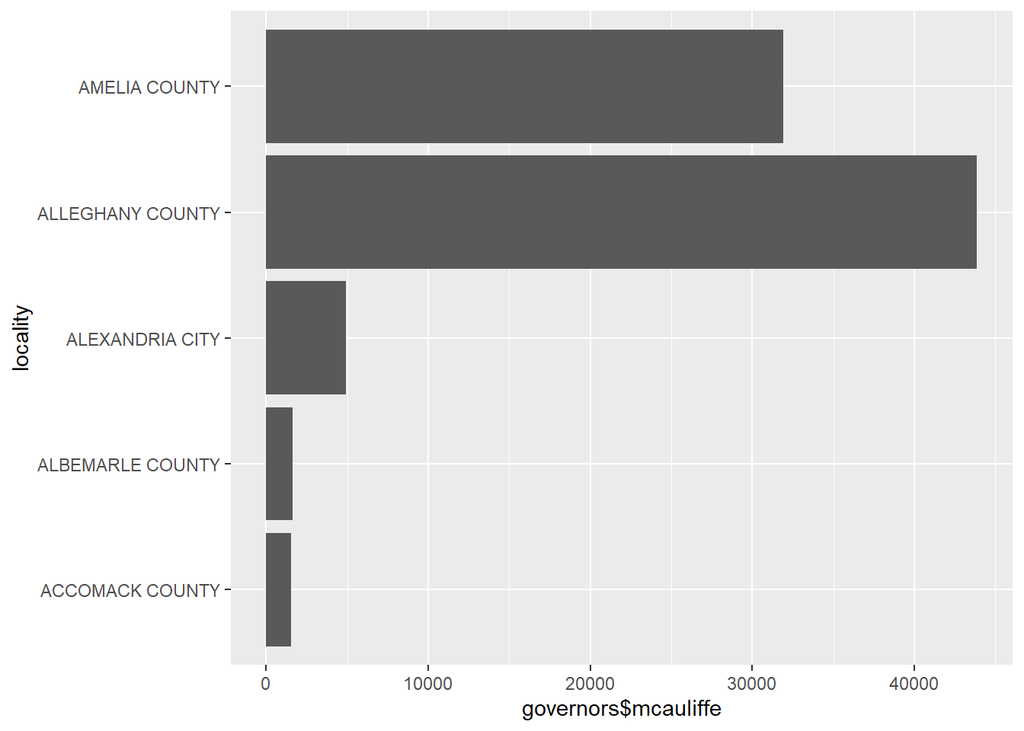

```r
#created another graph this time for mcauliffe

ggplot(governorvotes, aes(x = governors$mcauliffe, y = locality)) +
  geom_col()+
  scale_fill_manual(values = c("#468189", "#9DBEBB"))
```

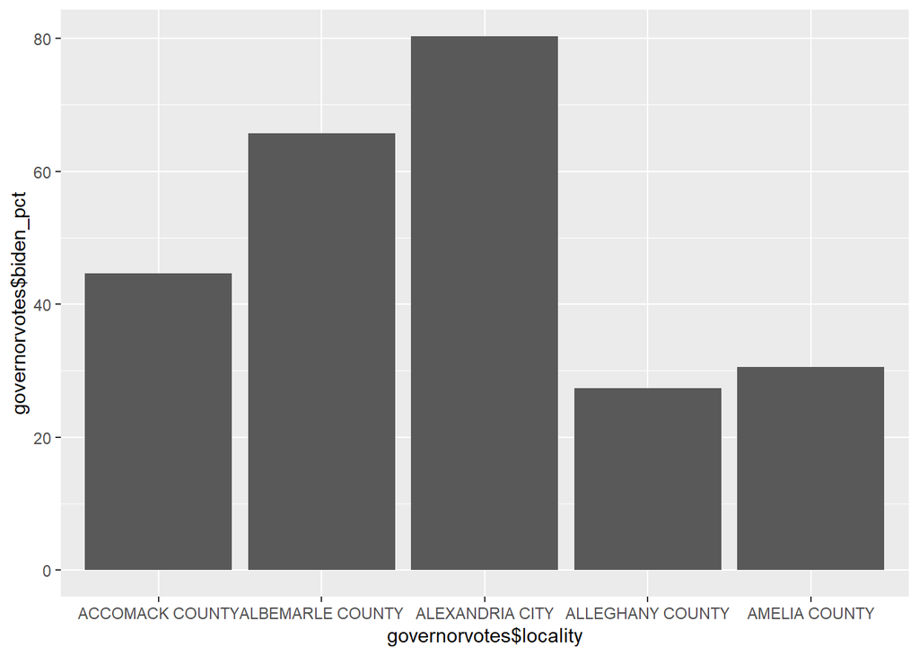

```r
#used code from above to compare biden's vote percentage in these counties compared to trump

ggplot(governorvotes, aes(x = governorvotes$biden_pct, y = governorvotes$locality)) +
  geom_col()+
  coord_flip()+
  scale_fill_manual(values = c("#468189", "#9DBEBB"))
```

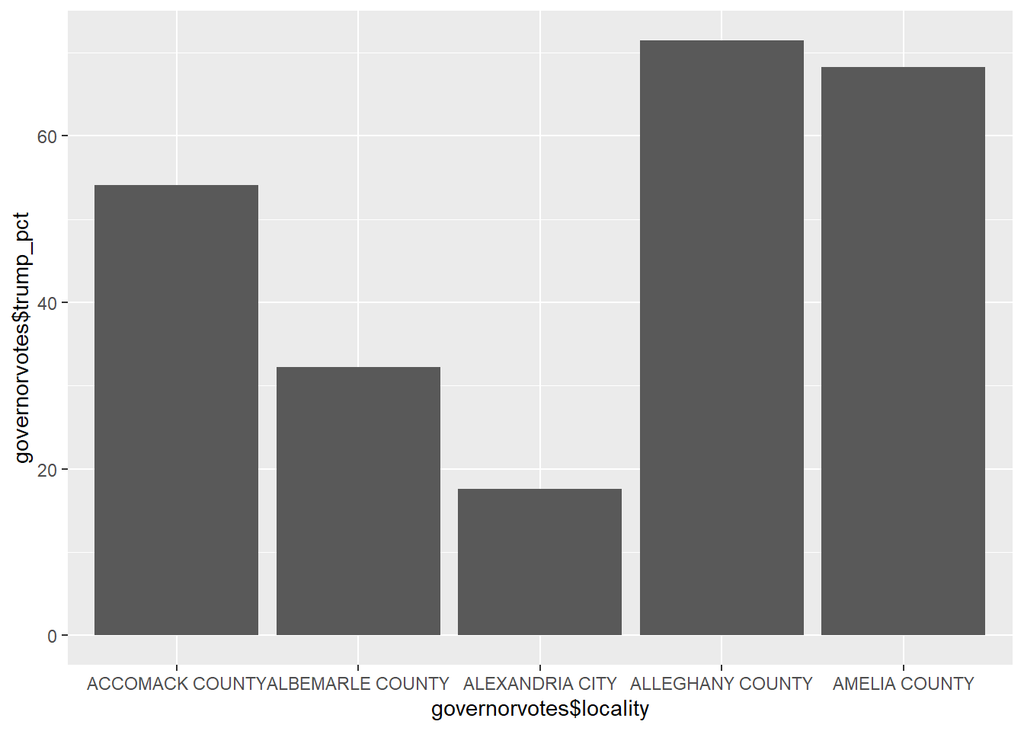

```r
ggplot(governorvotes, aes(x = governorvotes$trump_pct, y = governorvotes$locality)) +
  geom_col()+
  coord_flip()+
  scale_fill_manual(values = c("#468189", "#9DBEBB"))
```

Based on your own analysis, explain a third finding of your choosing, include a narrative explaining it to the audience and then create either a chart or table displaying it.

```r
#loaded fresh data set to create new data set
#that is grouped by the percentage of votes biden and trump received.
#used head to limit entries to 10
#repeated the above process for youngkin and mcauliffe
#created new data set by useing merge() to combine the presz_race
#and govs_race columns into pct_diff_elec data set. grouped this new data set by locality
#summarised this data set by creating a column called votecount from the meant of trump's % of votes subtracted from biden's
#used head() to inspect
#repeated process from previous chunk but this time for the gubernatorial race

joined_vacomparison <- readRDS(here("processed_data", "joined_vacomparison.rds"))

presZ_race <- (joined_vacomparison) %>%
  group_by(biden_pct, trump_pct) %>%
  head(10)

govs_race <- (joined_vacomparison)

govs_race <- (joined_vacomparison) %>%
  group_by(govs_race$pct_youngkin, govs_race$pct_mcauliffe) %>%
  head(5)


pct_diff_elec <- merge(govs_race, presZ_race) %>%
  group_by(locality) %>%
  summarise(presidentialmargin= mean(biden_pct-trump_pct))

head(pct_diff_elec)
```

```
# A tibble: 5 x 2
  locality         presidentialmargin
  <chr>                         <dbl>
1 ACCOMACK COUNTY               -9.39
2 ALBEMARLE COUNTY              33.5
3 ALEXANDRIA CITY               62.6
4 ALLEGHANY COUNTY             -44.1
5 AMELIA COUNTY                -37.7
```

```r
pct_diff_elec2 <- merge(govs_race, presZ_race) %>%
  group_by(locality) %>%
  summarise(gubernatorialmargin = mean(pct_youngkin-pct_mcauliffe))
head(pct_diff_elec2)
```

```
# A tibble: 5 x 2
  locality         gubernatorialmargin
  <chr>                          <dbl>
1 ACCOMACK COUNTY                 22.7
2 ALBEMARLE COUNTY               -24.8
3 ALEXANDRIA CITY                -51.2
4 ALLEGHANY COUNTY                49.6
5 AMELIA COUNTY                   48.8
```

In this table is the mean difference or gap of votes between presidential and gubernatorial candidates. The difference in votes seems to be slightly higher in the gubenatorial race compared to the presidential race.

[figure not shown]

```r
#creates graph from pct_diff_elec dataset

pct_diff_elec2 %>%
  ggplot(aes(x= reorder(locality, gubernatorialmargin), y = gubernatorialmargin))+
  geom_col(color = "#9ebcda", fill = "#9ebcda")+
  scale_y_continuous(name = "Votecount", labels = scales::comma) +
  scale_x_discrete(name = "County") +
  labs(title = "Mean Total votes between Governor and Presidential Candidates in Virginia",
       subtitle = "2020") +
  theme_classic()
```